# Tabular Playground Series: September 2022 Sales Forecasting

**Problem Description:**

For this challenge, you will be **predicting a full year worth of sales for 4 items from two competing stores located in six different countries**. This dataset is completely fictional, but contains many effects you see in real-world data, e.g., weekend and holiday effect, seasonality, etc. You are given the challenging task of predicting book sales during the year 2021.

Good luck!

Files

- train.csv - the training set, which includes the sales data for each date-country-store-item combination.
- test.csv - the test set; your task is to predict the corresponding item sales for each date-country-store-item combination. Note the Public leaderboard is scored on the first quarter of the test year, and the Private on the remaining.
- sample_submission.csv - a sample submission file in the correct format

# Import Libraries

```python
import pandas as pd
import numpy as np

import seaborn as sns
import matplotlib.pyplot as plt

from sklearn.preprocessing import StandardScaler
from sklearn.pipeline import make_pipeline
from sklearn.linear_model import Ridge

# Forecast
from sklearn.model_selection import GroupKFold
from sklearn.linear_model import Ridge
from sklearn.metrics      import r2_score
```

# EDA

## Data Description

```python
tr_dat = pd.read_csv("../input/tabular-playground-series-sep-2022/train.csv", parse_dates=["date"])
ts_dat = pd.read_csv("../input/tabular-playground-series-sep-2022/test.csv",  parse_dates=["date"])

print("Data Description: \n")

print("countries: ", tr_dat['country'].unique())
print("stores:    ", tr_dat['store'].unique())
print("products:  ", tr_dat['product'].unique())
print("\nyears in data:", tr_dat['date'].dt.year.unique())
```

```
Data Description:

countries:  ['Belgium' 'France' 'Germany' 'Italy' 'Poland' 'Spain']
stores:     ['KaggleMart' 'KaggleRama']
products:   ['Kaggle Advanced Techniques' 'Kaggle Getting Started'
 'Kaggle Recipe Book' 'Kaggle for Kids: One Smart Goose']

years in data: [2017 2018 2019 2020]
```

## Distribution by Country and Product

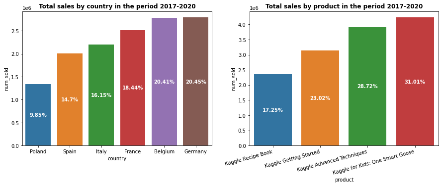

```python
from matplotlib import ticker

by_country = tr_dat.groupby(['country']).sum()['num_sold'].reset_index().sort_values(by='num_sold')
by_product = tr_dat.groupby(['product']).sum()['num_sold'].reset_index().sort_values(by='num_sold')
by_country['percent'] = np.round(by_country['num_sold']/by_country['num_sold'].sum() * 100, 2)
by_product['percent'] = np.round(by_product['num_sold']/by_product['num_sold'].sum() * 100, 2)

### create bar plots
f,ax=plt.subplots(ncols=2, figsize=(15,5))
sns.barplot(data = by_country, x='country', y='num_sold', ax=ax[0])
sns.barplot(data = by_product, x='product', y='num_sold', ax=ax[1])
ax[1].set_xticklabels(ax[1].get_xticklabels(), rotation=15, ha='right')

ax[0].set_title("Total sales by country in the period 2017-2020", fontweight='bold', fontsize=12)
ax[1].set_title("Total sales by product in the period 2017-2020", fontweight='bold', fontsize=12)

#### define ba labels
ax[0].bar_label(ax[0].containers[0],
                labels=[f"{el}%" for el in by_country['percent'].values],
                label_type='center', color='white', fontweight='bold')

ax[1].bar_label(ax[1].containers[0],
                labels=[f"{el}%" for el in by_product['percent'].values],
                label_type='center', color='white', fontweight='bold')

plt.show()
```

From 2017-2020:

- A great ammount of sales were achieve from Germany and Belgium.
- 'Kaggle for Kids: One Smart Goose' was the best seller.

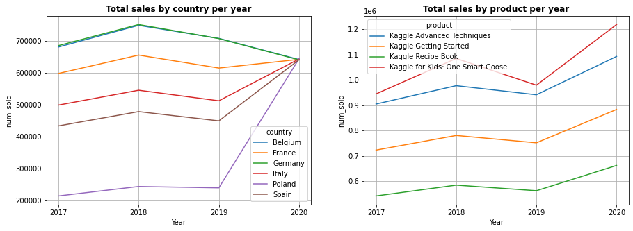

```python
tr_dat['Year'] = tr_dat['date'].dt.strftime('%Y')

data_by_country_year = tr_dat.groupby(['country','Year']).sum()['num_sold'].reset_index()# .sort_values(by=['country','Year'])
data_by_product_year = tr_dat.groupby(['product','Year']).sum()['num_sold'].reset_index()

f,ax=plt.subplots(ncols=2, figsize=(15,5))
sns.lineplot(data=data_by_country_year, x='Year', y='num_sold', hue='country', ax=ax[0])
sns.lineplot(data=data_by_product_year, x='Year', y='num_sold', hue='product', ax=ax[1])

ax[0].yaxis.set_major_locator(ticker.MultipleLocator(1e5))
ax[1].yaxis.set_major_locator(ticker.MultipleLocator(1e5))

ax[0].set_title("Total sales by country per year", fontweight='bold', fontsize=12)
ax[1].set_title("Total sales by product per year", fontweight='bold', fontsize=12)

ax[0].grid(True); ax[1].grid(True)
```

- Each product sales tendecy is similar to other products.
- At 2020, there was a strong change of tendency, all countries produce similar sales, even Poland which experiment the most drastic change in sales.

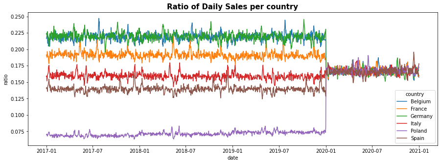

```python
temp  = tr_dat.groupby(['country','date']).sum()['num_sold'].reset_index()
temp3 = tr_dat.groupby(['date']).sum()['num_sold'].reset_index()['num_sold']
temp3 = np.concatenate([temp3,temp3,temp3,temp3,temp3,temp3])

temp['ratio'] = temp['num_sold']/temp3

f,ax=plt.subplots(figsize=(15,5))
ax.set_title('Ratio of Daily Sales per country', fontweight='bold', fontsize=15)
sns.lineplot(data=temp, x='date', y='ratio', hue='country')

plt.show()
```

- Ratio of sales per country in each store are similar, but, since January 2020, the rate of all countries change to be in similar proportions.
- This ratio also containes holidays, an extra effects, then is not suitable to obtain the mean an used to the next year.

## Sales by store

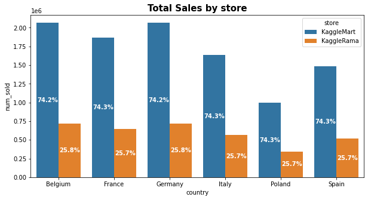

```python
data_by_store = tr_dat.groupby(['store','country']).sum()['num_sold'].reset_index().sort_values(by=['country','store'])
ratios_store  = (tr_dat.groupby(['country','store']).sum()['num_sold']/tr_dat.groupby(['country']).sum()['num_sold']).reset_index().sort_values(by=['country','store'])
data_by_store['ratio'] = ratios_store['num_sold'].values


f,ax = plt.subplots(figsize=(10,5))
ax.set_title("Total Sales by store", fontweight='bold', fontsize=15)
sns.barplot(data=data_by_store, x='country', y='num_sold', hue='store',ax=ax)

for i,store in enumerate(data_by_store['store'].unique()):
    ax.bar_label(ax.containers[i],
                 labels=[f'{round(el*100,1):.1f}%' for el in data_by_store[data_by_store['store']==store]['ratio'].values],
                 label_type='center', color='white', fontweight='bold')
```

- The ratio of sales per store is the same in all countries.

## Sales by product

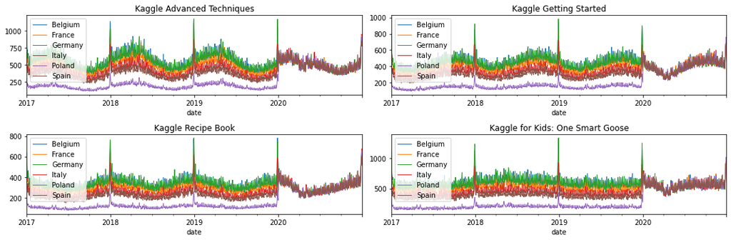

```python
f,ax=plt.subplots(figsize=(15,5), ncols=2, nrows=2)
for cnt, p in enumerate(tr_dat['product'].unique()):
    ax[cnt//2][cnt%2].set_title(p)
    tr_dat[(tr_dat['product']==p)].groupby(['date','country']).sum()['num_sold'].unstack(level=1).plot(kind='line', ax=ax[cnt//2][cnt%2], lw=1)
    ax[cnt//2][cnt%2].legend(loc='best')

plt.tight_layout()
```

The behaviour of the sales is summarized in total sales per product time series.

- Each product total sales has proportional tendecy in each country.
- High rate of sales at last period
- Seasonal Sales, high peaks observed at new eve.
- The last period shows that a drastic sales tendency (COVID19 lockdown?), similar sales are expected independently of the country for each product.

There is a drastic change of the tendecy at the begining of 2020.

As stated [here](https://www.kaggle.com/competitions/tabular-playground-series-sep-2022/discussion/349737). The percentage of which products sold by date is cyclical.

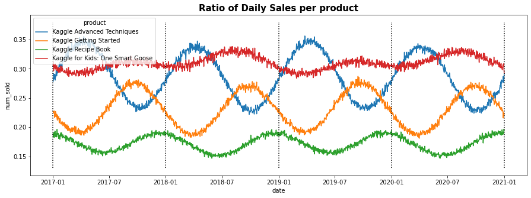

```python
data_product = (tr_dat.groupby(["date",'product']).sum()['num_sold']/tr_dat.groupby(["date"]).sum()['num_sold']).reset_index()

f,ax=plt.subplots(figsize=(15,5))
ax.set_title("Ratio of Daily Sales per product", fontweight='bold', fontsize=15)
sns.lineplot(data=data_product, x='date', y='num_sold', hue='product')
ax.vlines(x=[np.datetime64(y) for y in ['2017','2018','2019','2020','2021']], ymin=0.13, ymax=0.38, color='black', linestyles='dotted')

plt.show()
```

- Ratios of sales are mantained over time

This can suggests a multiplicative decomposition of the time series sales.

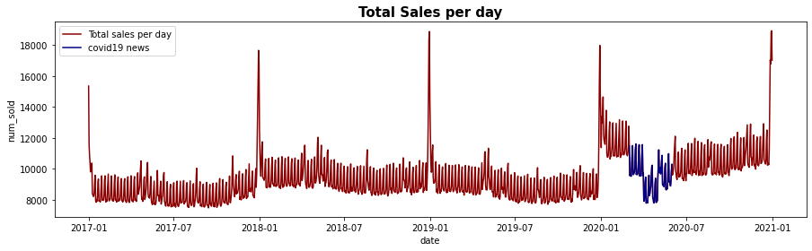

```python
temp1        = tr_dat.groupby(['date']).sum()['num_sold'].reset_index()
temp1['woy'] = temp1['date'].dt.isocalendar().week
temp1['dow'] = temp1['date'].dt.dayofweek
temp1['doy'] = temp1['date'].dt.dayofyear

f,ax=plt.subplots(figsize=(15,4))
period_ind = (temp1['date']>='2020-03-01')&(temp1['date']<'2020-06-01')

ax.set_title("Total Sales per day", fontweight='bold', fontsize=15)
sns.lineplot(data=temp1, x='date', y='num_sold', ax=ax, color='darkred', label='Total sales per day')
sns.lineplot(data=temp1[period_ind], x='date', y='num_sold', ax=ax, color='navy', label='covid19 news')
plt.show()
```

- Total Daily sales during 2020 were affected by a global crisis (COVID lockdown), this is not expected to occur annually, the specific period from '2020-03-01' to '2020-06-01' may be ignored for model training.
- There is a tendency for peaks during the week, this can be used to refine the model, for example, more sales are expected on Friday than on Monday.

## Holiday Sales Modeling

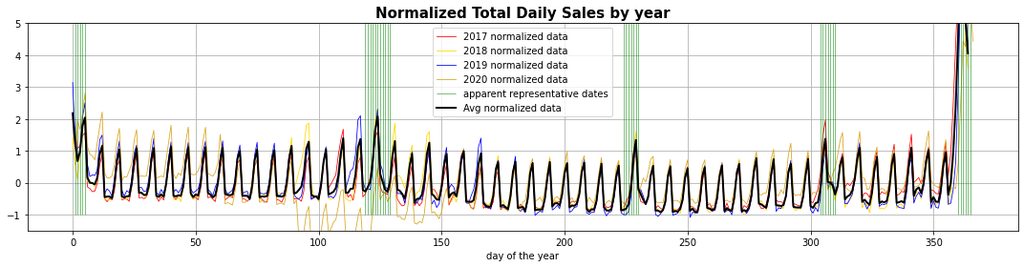

```python
## Holiday sales modeling
#from statsmodels.tsa.filters.hp_filter import hpfilter

t1 = temp1[temp1['date'].dt.year==2017]
t2 = temp1[temp1['date'].dt.year==2018]
t3 = temp1[temp1['date'].dt.year==2019]
t4 = temp1[(temp1['date'].dt.year==2020)] #&~((temp1['date']>='2020-03-01')&(temp1['date']<'2020-06-01'))]


# to compare years it is necessary to move day-of-year until weekends overlap
t4_val = t4['num_sold'].values
t3_val = t3['num_sold'].values
t2_val = np.concatenate([t2['num_sold'].values[1:],t3_val[-1:]])
t1_val = np.concatenate([t1['num_sold'].values[2:],t3_val[-2:]])

# apply mean normalization
t1_val = (t1_val-t1_val.mean())/t1_val.std()
t2_val = (t2_val-t2_val.mean())/t2_val.std()
t3_val = (t3_val-t3_val.mean())/t3_val.std()
t4_val = (t4_val-t4_val.mean())/t4_val.std()
t5 = (t1_val+t2_val+t3_val)/3  # mean of non leap years

# representation
f,ax=plt.subplots(figsize=(15,4))

ax.plot(t1_val,color='red', label='2017 normalized data', lw=0.8)
ax.plot(t2_val,color='gold' , label='2018 normalized data', lw=0.8)
ax.plot(t3_val,color='blue', label='2019 normalized data', lw=0.8)
ax.plot(t4['doy'].values,t4_val,color='goldenrod', label='2020 normalized data', lw=0.8)


rep_dates = [1,2,3,4,5,
             119,120,121,122,123,124,125,126,127,128,129,
             224,225,226,227,228,229,230,
             304,305,306,307,308,309,310,
             360,361,362,363,364,365]

ax.vlines(rep_dates,ymin=-1,ymax=9,color='green',label='apparent representative dates', lw=0.5)
ax.plot(t5, lw=2,color='black', label='Avg normalized data')

#sm_factor = hpfilter(t5, lamb=50)
#ax.plot(sm_factor[1], lw=2,color='darkred', label='hpfilter')

ax.set_title('Normalized Total Daily Sales by year', fontweight='bold', fontsize=15)
ax.set_xlabel('day of the year')
ax.grid()
ax.set_ylim([-1.5, 5])
ax.legend(loc='best')

plt.tight_layout()
plt.show()
```

### Holidays

```python
from holidays import Belgium, France, Germany, Italy, Poland, Spain
from datetime import datetime

def obtain_hollidays(country):
    temp = pd.to_datetime(pd.Series(country(years=[2020]).keys())).dt.dayofyear.values
    temp = temp - (temp >=29)
    temp = np.concatenate([pd.to_datetime(pd.Series(Belgium(years=[2017,2018,2019,2020,2021]).keys())).dt.dayofyear.values, temp])
    t_dir = {el:0 for el in temp}

    for el in temp:
        t_dir[el] = t_dir[el]+1

    return [el[0] for el in t_dir.items() if el[1]>=4]

print('Holidays:\n')
print('Belgium: ',obtain_hollidays(Belgium))
print('France:  ',obtain_hollidays(France))
print('Germany: ',obtain_hollidays(Germany))
print('Italy:   ',obtain_hollidays(Italy))
print('Poland:  ',obtain_hollidays(Poland))
print('Spain:   ',obtain_hollidays(Spain))
```

```
Holidays:

Belgium:  [1, 121, 202, 227, 305, 315, 359]
France:   [1, 121, 202, 227, 305, 315, 359]
Germany:  [1, 121, 202, 227, 305, 315, 359]
Italy:    [1, 121, 202, 227, 305, 315, 359]
Poland:   [1, 121, 202, 227, 305, 315, 359]
Spain:    [1, 121, 202, 227, 305, 315, 359]
```

**This effect can be included in feature engineering using the radial basis function around selected dates.**.

## Intraweek sales tendency

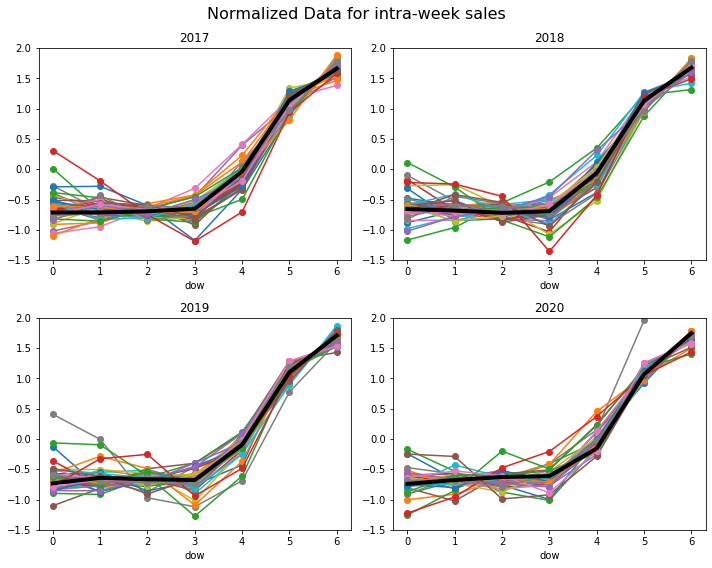

```python
# select complete weeks available only
t_2017 = temp1[temp1['date'].dt.year==2017][1:]
t_2018 = temp1[temp1['date'].dt.year==2018][:-1]
t_2019 = temp1[temp1['date'].dt.year==2019][:-2]
t_2020 = temp1[(temp1['date'].dt.year==2020)&~((temp1['date']>='2020-03-01')&(temp1['date']<'2020-06-01'))]

def tend_week(t_data):
    tp = t_data.groupby(['dow']).mean()['num_sold']
    tp = (tp - tp.mean())/tp.std()
    return tp.values


f,ax=plt.subplots(figsize=(10,8), ncols=2, nrows=2)

avg_tend = []
for n,data in enumerate([t_2017, t_2018, t_2019, t_2020]):
    avg_tend.append(tend_week(data))
    for i in range(2,50):
        t1 = data[data['woy']==i].set_index('dow')
        # mean normalization
        t1 = (t1['num_sold']-t1['num_sold'].mean())/t1['num_sold'].std()

        t1.plot(ax=ax[n//2][n%2], marker='o', label=i)

        ax[n//2][n%2].set_title(n+2017)
        ax[n//2][n%2].set_ylim([-1.5, 2.0])

    ax[n//2][n%2].plot(tend_week(data), color='black', lw=4)

f.suptitle('Normalized Data for intra-week sales', fontsize=16)
plt.tight_layout()
```

Normalized data for intra-week sales shows that there is a cyclic sales tendency for each day of the week (dow). This effect can be used during feature enginering. This is defined:

- dow <= 3 => weight of 0 (from Monday to Thursday low sales are expected)
- dow == 4 => weight of 1 (by Friday, there are more sales)
- dow == 5 => weight of 2 (by Saturday, there are more sales than Friday)
- dow == 6 => weight of 3 (by Sunday, there are more sales than Saturday)

## Propotions of Sales per Country

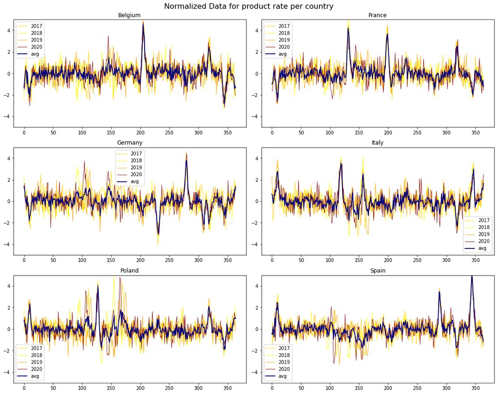

```python
#grouped country weight calculation
country_df = tr_dat.groupby(["date","country"])["num_sold"].sum().reset_index()

country_weight_df = country_df.pivot(index="date", columns="country", values="num_sold")
country_weight_df = country_weight_df.apply(lambda x: x/x.sum(),axis=1)    # normalized to [0 --1] axis=1 rows
country_weight_df = country_weight_df.stack().rename("country_w").reset_index()

########################
temp = country_weight_df.pivot(index='date', columns='country', values='country_w').reset_index()
temp['year']  = temp['date'].dt.year

# correction to dramatic change at 1st Jan 2020
ref = ['Belgium','France','Germany','Italy','Poland','Spain']
temp.loc[temp['date']=='2020-01-01',ref] = temp.loc[temp['date']=='2020-01-02',ref].values

means = temp.groupby('year').mean() ; stds  = temp.groupby('year').std()
for year in [2017, 2018, 2019, 2020]:
    temp.loc[temp['year']==year,ref] -=means.loc[year].values
    temp.loc[temp['year']==year,ref] /=stds.loc[year].values

colors =['gold','yellow','orange','darkred']
country_rate = {}

f, ax = plt.subplots(figsize=(15,12), ncols=2, nrows=3)
for n_c, country in enumerate(ref):
    avg_rate = 0
    for year, g in temp.groupby("year"):
        if year==2020: g = g[g['date']!='2020-02-29']
        t1 = g[country].values
        ax[n_c//2][n_c%2].plot(t1, label=year, color=colors[year-2017], lw=0.8)
        avg_rate +=t1

    country_rate[country] = avg_rate/4
    ax[n_c//2][n_c%2].plot(avg_rate/4, label='avg', color='navy', lw=1.8)
    ax[n_c//2][n_c%2].set_ylim([-5,5]); ax[n_c//2][n_c%2].set_title(country)
    ax[n_c//2][n_c%2].legend()

f.suptitle('Normalized Data for product rate per country', fontsize=16)
plt.tight_layout() ; plt.show()
```

Comparing the z-score normalized daily sales tendency by country, similarities can be found. Notice that there is a certain sales tendecy encoded along the years per country, the averaged proportion of sales can be useful to define a forecast model.

# Forecast model

From EDA's insights, the target (daily sales by country, store and product) can be expresed as a multiplicative decomposition. The following equation is proposed:

$$y_{t}^{c,s,p} = T_{t} R_{t}^{p} m^{s} r_{t}^{c}$$

where:

- $\sum{R_{t}^{p}}=1$, $\sum{m^{s}}=1$
- $T_{t}$ is the seasonal yearly trend of total number of daily sales, at a give day $t$.
- $R_{t}^{p}$ is the cylic product sales ratio of a given product $p$ at a given day $t$.
- $m^{s}$ is the proportion of sales at a given store $s$.
- $r_{t}^{c}$ is the proportion of sales for a specific country $c$ at a given day $t$.
- $y_{t}^{c,s,p}$ is the total number of sales of a product $p$ from a country $c$, store $s$ at a given day $t$.

Since $R_{t}^{p}$ and $r_{t}^{c}$ are periodic and $m^{s}$ is fixed, the forecasting problem can be simplified to just predict $T$ total number of daily sales for 2021.

## Model for Total Daily Sales *T*

```python
#remove covid dates
train_nocovid_df = tr_dat.groupby(['date']).sum()['num_sold'].reset_index()
train_nocovid_df = train_nocovid_df.loc[~((train_nocovid_df["date"]>="2020-03-01") & (train_nocovid_df["date"]<"2020-06-01"))]

total_tr_df = train_nocovid_df
#get the dates to forecast for # just a complex way to obtain the data from the test file
ts_dates = ts_dat.groupby(["date"])["row_id"].first().reset_index().drop(columns="row_id")
test_all_df_dates = ts_dates[['date']]
```

```python
# Holiday 'day-of-year' selected
#                    (amplitude, day-of-year)
radial_basis_info = [(20,  1),   (200, 121), (50, 191),
                     (150, 202), (400, 227), (1000, 315),
                     (800, 359), (10,  365)]
#[1,121,202,227,305,315,359,365]

def feature_engineer(df):
    new_df = df.copy()
    # add non-linear features for modelling
    new_df["month"]   = new_df["date"].dt.month
    new_df["month_sin"] = np.sin(new_df['month'] * (2 * np.pi / 12))

    # weighted weeks days [1-3]:0, [4]:1, [5]:2, [6,7]:3
    new_df["day_of_week"] = df["date"].dt.dayofweek
    new_df["day_of_week"] = new_df["day_of_week"].apply(lambda x: 0 if x<=3 else (1 if x==4 else (2 if x==5 else (3))))

    new_df["day_of_year"] = df["date"].dt.dayofyear
    #account for leap year, remove the change in numeration due to 29th Feb 2020
    new_df["day_of_year"] = new_df.apply(lambda x: x["day_of_year"]-1 if (x["date"] > pd.Timestamp("2020-02-29") and x["date"] < pd.Timestamp("2021-01-01"))  else x["day_of_year"], axis=1)

    # radial basis function for selected dates
    for el in radial_basis_info:
        amplt=el[0]; day=el[1]
        new_df[f'x_{day}'] = new_df['day_of_year'].apply(lambda x: np.exp((x-day)**2 /(-2*amplt)))

    new_df["year"] = df["date"].dt.year
    new_df = new_df.drop(columns=["date","month","day_of_year"])

    # convert categorical into indicative variables (onehot version)
    new_df = pd.get_dummies(new_df, columns = ["day_of_week"], drop_first=True)

    return new_df

train_all_df = feature_engineer(total_tr_df)
test_all_df  = feature_engineer(ts_dates)
```

```python
X = train_all_df.drop(columns="num_sold")
y = train_all_df["num_sold"]
X_test = test_all_df

preds_lst = []
kf = GroupKFold(n_splits=4)

for fold, (train_idx, val_idx) in enumerate(kf.split(X, groups=X.year)):
    model = Ridge(alpha=0.5, solver='sag')
    model = make_pipeline(StandardScaler(), model)
    model.fit(X.iloc[train_idx], y.iloc[train_idx])
    preds_lst.append(model.predict(X_test))

    #sc =  model.score(X.iloc[val_idx], y.iloc[val_idx])
    #print(fold, X.iloc[val_idx]['year'].unique(), sc)

preds_df = pd.DataFrame(np.column_stack(preds_lst), columns = ["2017", "2018", "2019", "2020"])

#average predictions from kfold
preds_df['num_sold'] = preds_df.sum(axis=1)/len(preds_lst)
test_all_df_dates["num_sold"] = preds_df['num_sold']
```

[figure not shown]

```python
f,ax=plt.subplots(figsize=(15,8), nrows=2)

t1 = preds_df['num_sold'].values
# mean normalization
comp1 = (t1-t1.mean())/t1.std()

ax[0].plot(t1,label='total sales predicted',color='darkred')

# overlap weekend peaks
ax[1].plot(np.linspace(-3,361,365),t5, label='tendency', color='black', lw=2)
ax[1].plot(comp1, label='total sales predicted', color='navy', lw=1)

ax[0].grid()                  ; ax[1].grid()
ax[0].set_ylim([9000, 15000]) ; ax[1].set_ylim([-1.5, 6])
ax[0].set_xlim([-10, 370])    ; ax[1].set_xlim([-10, 370])
ax[0].legend(loc='best')      ; ax[1].legend(loc='best')
ax[0].set_title('Predicted Sales for 2021', fontsize=15, fontweight='bold')
ax[1].set_title('Normalized Predicted Sales vs expected tendecy', fontsize=15, fontweight='bold')

plt.legend() ; plt.show()
```

- The normalized tendency for the 2021 forcasted sales has the same tendency of previous years.
- A Rigde model with K-Fold validation was sufficient. The Linear Model is capable of this thanks to the encoding non-linear features:
  - sinusoidal month (sin(month)) for cyclic effects
  - holiday effects, radial basis functions to simulation sales tendency around holidays.
  - intra-week tendency, weights according day of the week.

## Cyclic sales ratios per product *R*

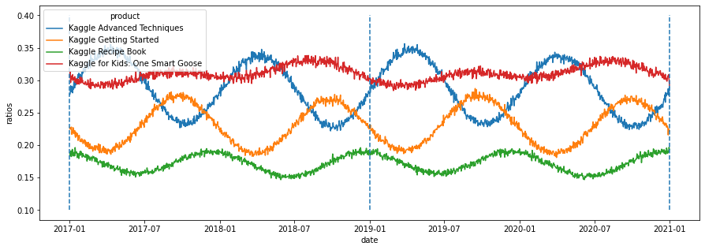

```python
#product ratios per day
#grouped for ratio calculation
product_df = tr_dat.groupby(["date","product"])["num_sold"].sum().reset_index()

product_ratio_df = product_df.pivot(index="date", columns="product", values="num_sold")
product_ratio_df = product_ratio_df.apply(lambda x: x/x.sum(),axis=1)                      # normalized to [0 --1] axis=1 rows
product_ratio_df = product_ratio_df.stack().rename("ratios").reset_index()

seas_ratio = product_ratio_df[(product_ratio_df["date"].dt.year==2017)|
                              (product_ratio_df["date"].dt.year==2019)].copy()

seas_ratio["mm-dd"] = seas_ratio["date"].dt.strftime('%m-%d')
seas_ratio = seas_ratio.drop(columns="date")
seas_ratio = seas_ratio.groupby(['mm-dd','product']).mean().reset_index()

############ Two year cycle
f,ax=plt.subplots(figsize=(15,5))
sns.lineplot(data=product_ratio_df, x='date', y='ratios', hue='product',ax=ax)
ax.vlines(['2017','2019','2021'], ymin=0.1, ymax=0.4, linestyle='dashed')

plt.show()
```

Empirical observation indicates that there is a two year cycle for the sales ratio of 'Kaggle for Kids: One Smart Goose', to e this cycle as yearly the mean of them is used.

## $T_{t} R_{t}^{p}$ Total product sales per day calculation

```python
test_sub_df = pd.merge(ts_dat, test_all_df_dates, how="left")

# distribute ratios R_t
test_sub_df["mm-dd"]  = test_sub_df["date"].dt.strftime('%m-%d')
test_product_ratio_df = pd.merge(test_sub_df, seas_ratio, how="left", on = ["mm-dd","product"])

#test_product_ratio_df.head()  # seasonal tendency included
```

## Proporion of sales per store $m^{s}$

```python
#ratio sold by store
store_weights = tr_dat.groupby("store")["num_sold"].sum()/tr_dat["num_sold"].sum()
store_weights.reset_index()
```

|  | store | num_sold |
| --- | --- | --- |
| 0 | KaggleMart | 0.742515 |
| 1 | KaggleRama | 0.257485 |

## Propotion of sales per Country and day $r_{t}^{c}$

```python
country_weight_avg_df = pd.DataFrame(country_rate)
country_weight_avg_df['mm-dd'] = ts_dates['date'].dt.strftime('%m-%d')
#country_weight_avg_df['mm-dd'] = country_weight_avg_df['date']

country_weight_avg_df.loc[:,ref] *= stds.loc[2020].values
country_weight_avg_df.loc[:,ref] += means.loc[2020].values

country_weight_avg_df = country_weight_avg_df.melt(id_vars=["mm-dd"], var_name="country", value_name="country_w_avg")
#country_weight_avg_df.head()
```

## Estimate daily sales by country, store and product

```python
final = pd.merge(test_product_ratio_df, country_weight_avg_df[['country','country_w_avg','mm-dd']], how="left", on = ["mm-dd","country"])
final['num_sold_avg']   = final['num_sold'] * final['ratios'] * final['country_w_avg']

for store in store_weights.index:
    ind = final["store"] == store
    final.loc[ind, "num_sold_avg"]   = final.loc[ind, "num_sold_avg"]   * store_weights[store]


#output = pd.DataFrame({'row_id':   final['row_id'],
#                       'num_sold': final['num_sold_avg'].round()})

#output.to_csv('submission_v8.csv', index=False)
```

# Forecasted sales analysis

```python
final = final[['date','country','store','product','num_sold_avg']].copy()
final['Year'] = 2021
```

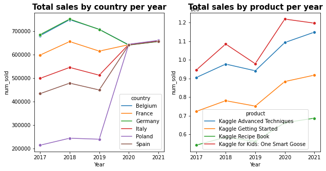

```python
temp = tr_dat.groupby(['country','Year'])['num_sold'].sum().reset_index()
forecast_temp = (final.groupby(['country','Year'])['num_sold_avg']
                 .sum().reset_index()
                 .rename(columns={"num_sold_avg": "num_sold"}))

temp = pd.concat([temp,forecast_temp], ignore_index=True).sort_values(by=['country','Year'])

temp1 = tr_dat.groupby(['product','Year'])['num_sold'].sum().reset_index()
forecast_temp1 = (final.groupby(['product','Year'])['num_sold_avg']
                 .sum().reset_index()
                 .rename(columns={"num_sold_avg": "num_sold"}))

temp1 = pd.concat([temp1,forecast_temp1], ignore_index=True).sort_values(by=['product','Year'])
temp['Year'] = temp['Year'].astype("int")
temp1['Year'] = temp1['Year'].astype("int")

f,ax=plt.subplots(ncols=2, figsize=(10,5))
ax[0].set_title("Total sales by country per year", fontsize=15, fontweight='bold')
ax[1].set_title("Total sales by product per year", fontsize=15, fontweight='bold')

#ax[0].xaxis.set_major_locator(ticker.MultipleLocator(1))
#ax[1].xaxis.set_major_locator(ticker.MultipleLocator(1))

sns.lineplot(data=temp, x='Year', y='num_sold', hue='country', marker='o', ax=ax[0])
sns.lineplot(data=temp1, x='Year', y='num_sold', hue='product', marker='o', ax=ax[1])
plt.show()
```

```python
print(temp[temp['Year']==2021].set_index('country')['num_sold']/temp[temp['Year']==2020]['num_sold'].values - 1)
print("*"*50)
print(temp1[temp1['Year']==2021].set_index('product')['num_sold']/temp1[temp1['Year']==2020]['num_sold'].values - 1)
```

```
country
Belgium    0.023211
France     0.023638
Germany    0.023505
Italy      0.024031
Poland     0.025639
Spain      0.024320
Name: num_sold, dtype: float64
product
Kaggle Advanced Techniques          0.050964
Kaggle Getting Started              0.038923
Kaggle Recipe Book                  0.037137
Kaggle for Kids: One Smart Goose   -0.017946
Name: num_sold, dtype: float64
```